# Company Layoffs Data Analysis

### Steps to take

#### 1. **Data cleaning**(check duplicates, standardize data, manage NULL values entries, drop unnecessary rows and columns)

#### 2. **Exploratory Data Analysis** (Visualization of the following inquiries with an emphasis on US impact):

#### - Top 10 industries by percentage laid off Globally

#### - Top 10 industries by percentage laid off in United States

#### - Top 10 industries with the largest gap in percentage laid off Global vs United States

#### - Total monthly United States vs Global layoffs

#### - Top 10 United States Locations by Total Laid Off

#### - Top 10 United States Companies by Total Laid Off

### Import libraries

```python
import pandas as pd
import numpy as np
import seaborn as sns
import matplotlib
import matplotlib.pyplot as plt
plt.style.use('ggplot')
from matplotlib.pyplot import figure

%matplotlib inline
matplotlib.rcParams['figure.figsize'] = (15, 6) # resizing the plot
```

```python
df = pd.read_csv(r"D:\Analyst materials\projects\files\layoffs_raw.csv")
df.head()
```

|  | company | location | industry | total_laid_off | percentage_laid_off | date | stage | country | funds_raised_millions |
| --- | --- | --- | --- | --- | --- | --- | --- | --- | --- |
| 0 | Atlassian | Sydney | Other | 500.0 | 0.05 | 3/6/2023 | Post-IPO | Australia | 210.0 |
| 1 | SiriusXM | New York City | Media | 475.0 | 0.08 | 3/6/2023 | Post-IPO | United States | 525.0 |
| 2 | Alerzo | Ibadan | Retail | 400.0 | NaN | 3/6/2023 | Series B | Nigeria | 16.0 |
| 3 | UpGrad | Mumbai | Education | 120.0 | NaN | 3/6/2023 | Unknown | India | 631.0 |
| 4 | Loft | Sao Paulo | Real Estate | 340.0 | 0.15 | 3/3/2023 | Unknown | Brazil | 788.0 |

```python
df.info()
```

```
<class 'pandas.core.frame.DataFrame'>
RangeIndex: 2361 entries, 0 to 2360
Data columns (total 9 columns):
 #   Column                 Non-Null Count  Dtype
---  ------                 --------------  -----
 0   company                2361 non-null   object
 1   location               2361 non-null   object
 2   industry               2357 non-null   object
 3   total_laid_off         1621 non-null   float64
 4   percentage_laid_off    1576 non-null   float64
 5   date                   2360 non-null   object
 6   stage                  2355 non-null   object
 7   country                2361 non-null   object
 8   funds_raised_millions  2152 non-null   float64
dtypes: float64(3), object(6)
memory usage: 166.1+ KB
```

## First, we do some data cleaning

### Check and remove duplicates

```python
df[df.duplicated()]
```

|  | company | location | industry | total_laid_off | percentage_laid_off | date | stage | country | funds_raised_millions |
| --- | --- | --- | --- | --- | --- | --- | --- | --- | --- |
| 1492 | Cazoo | London | Transportation | 750.0 | 0.15 | 6/7/2022 | Post-IPO | United Kingdom | 2000.0 |
| 2357 | Yahoo | SF Bay Area | Consumer | 1600.0 | 0.20 | 2/9/2023 | Acquired | United States | 6.0 |
| 2358 | Hibob | Tel Aviv | HR | 70.0 | 0.30 | 3/30/2020 | Series A | Israel | 45.0 |
| 2359 | Casper | New York City | Retail | NaN | NaN | 9/14/2021 | Post-IPO | United States | 339.0 |
| 2360 | Wildlife Studios | Sao Paulo | Consumer | 300.0 | 0.20 | 11/28/2022 | Unknown | Brazil | 260.0 |

```python
df = df.drop_duplicates()
```

### Since I did the project in SQL first, I know there are some extra white spaces around company names, dots around country names, and the `Crypto` industry having multiple names. This is done by manually looking into the columns of the table in SQL

### Stripping extra white spaces around company names

```python
df.loc[:, 'company'] = df['company'].str.strip()
```

### Stripping extra dots (.) around country names

```python
df['country'] = df['country'].str.rstrip('.')
```

### Collapsing all Crypto industries into `Crypto`

```python
df.loc[df['industry'].str.startswith('Crypto', na=False), 'industry'] = 'Crypto'
```

### Converting `date` data type to date

```python
df['date'] = pd.to_datetime(df['date'])
```

### Check null values

```python
df.isnull().sum()
```

```
company                    0
location                   0
industry                   4
total_laid_off           739
percentage_laid_off      784
date                       1
stage                      6
country                    0
funds_raised_millions    209
dtype: int64
```

### Drop rows where both `total_laid_off` and `percentage_laid_off` are null (since the exploratory analysis will rely on these values)

```python
df = df.dropna(subset=['total_laid_off', 'percentage_laid_off'], how='all')
```

### Filling in `industry` if there are matching entries(same company and location) elsewhere with `industry` populated

```python
pd.set_option('future.no_silent_downcasting', True)
df['industry'] = df.groupby(['company', 'location'])['industry'].transform(lambda x: x.ffill())
df['industry'] = df.groupby(['company', 'location'])['industry'].transform(lambda x: x.bfill())
```

### Check for remaining null industries

```python
df[df['industry'].isna()]
```

|  | company | location | industry | total_laid_off | percentage_laid_off | date | stage | country | funds_raised_millions |
| --- | --- | --- | --- | --- | --- | --- | --- | --- | --- |
| 330 | Bally's Interactive | Providence | NaN | NaN | 0.15 | 2023-01-18 | Post-IPO | United States | 946.0 |

### There is still 1 company with null industry, we can fill it in

```python
df['industry'] = df['industry'].fillna('Other')
```

## Now, we perform Exploratory Data Analysis with an emphasis on US impact

### Top 10 industries by percentage laid off Globally

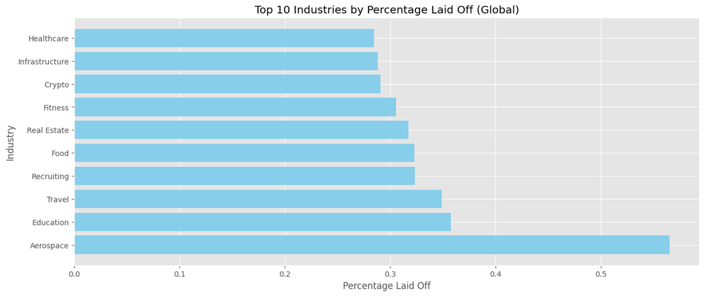

```python
global_top10 = df.groupby('industry')['percentage_laid_off'].mean().nlargest(10).reset_index()

plt.barh(global_top10['industry'], global_top10['percentage_laid_off'], color='skyblue')
plt.xlabel('Percentage Laid Off')
plt.ylabel('Industry')
plt.title('Top 10 Industries by Percentage Laid Off (Global)')

plt.show()
```

### Top 10 industries by percentage laid off in United States

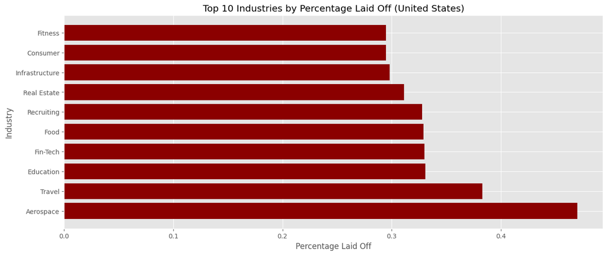

```python
us_top10 = (df[df['country'] == 'United States'].groupby('industry')['percentage_laid_off'].mean().nlargest(10).reset_index())

plt.barh(us_top10['industry'], us_top10['percentage_laid_off'], color='darkred')
plt.xlabel('Percentage Laid Off')
plt.ylabel('Industry')
plt.title('Top 10 Industries by Percentage Laid Off (United States)')

plt.show()
```

### Top 10 industries with the largest gap in percentage laid off Global vs United States

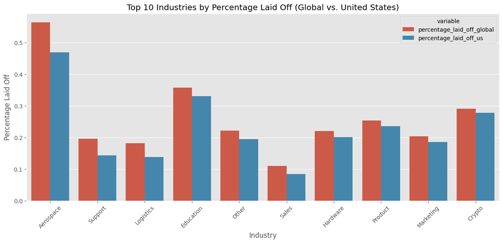

```python
# getting percentage laid off for global and US
global_avg = df.groupby('industry')['percentage_laid_off'].mean().reset_index()
us_avg = df[df['country'] == 'United States'].groupby('industry')['percentage_laid_off'].mean().reset_index()

# getting the top 10 percentage gaps between global and US
global_avg.rename(columns={'percentage_laid_off': 'percentage_laid_off_global'}, inplace=True)
us_avg.rename(columns={'percentage_laid_off': 'percentage_laid_off_us'}, inplace=True)
compare = pd.merge(global_avg, us_avg, on='industry', how='outer')
compare['gap'] = compare['percentage_laid_off_global'] - compare['percentage_laid_off_us']
top_10_gap = compare.nlargest(10, 'gap').reset_index(drop=True)

sns.barplot(data=top_10_gap.melt(id_vars='industry', value_vars=['percentage_laid_off_global', 'percentage_laid_off_us']),
            x='industry', y='value', hue='variable')

plt.title('Top 10 Industries by Percentage Laid Off (Global vs. United States)')
plt.xlabel('Industry')
plt.ylabel('Percentage Laid Off')
plt.xticks(rotation=45)

plt.show()
```

### Total monthly United States vs Global layoffs

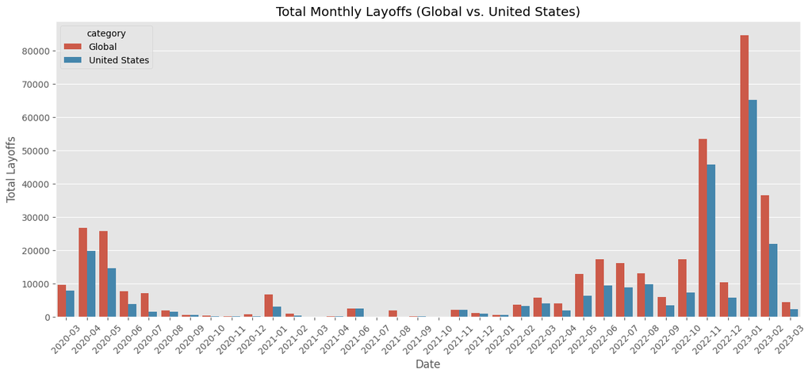

```python
df['month_year'] = df['date'].dt.to_period('M')
global_layoffs = df.groupby('month_year')['total_laid_off'].sum().reset_index()
global_layoffs['category'] = 'Global'
us_layoffs = df[df['country'] == 'United States'].groupby('month_year')['total_laid_off'].sum().reset_index()
us_layoffs['category'] = 'United States'
layoffs_combined = pd.concat([global_layoffs, us_layoffs])

sns.barplot(data=layoffs_combined, x='month_year', y='total_laid_off', hue='category')
plt.title('Total Monthly Layoffs (Global vs. United States)')
plt.xlabel('Date')
plt.ylabel('Total Layoffs')
plt.xticks(rotation=45)

plt.show()
```

### Top 10 United States Locations by Total Laid Off

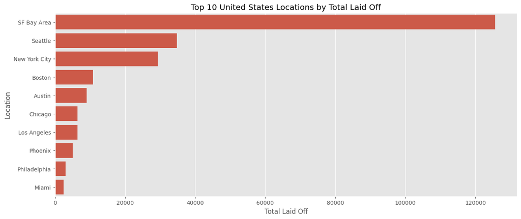

```python
us_grouped = df[df['country'] == 'United States'].groupby('location')['total_laid_off'].sum().reset_index()
top_10_us_locations = us_grouped.sort_values(by='total_laid_off', ascending=False).head(10)

sns.barplot(x='total_laid_off', y='location', data=top_10_us_locations)
plt.title('Top 10 United States Locations by Total Laid Off')
plt.xlabel('Total Laid Off')
plt.ylabel('Location')

plt.show()
```

### Top 10 United States Companies by Total Laid Off

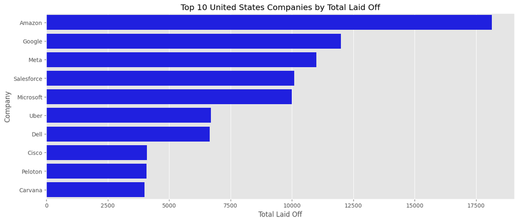

```python
us_data = df[df['country'] == 'United States']

top_10_us_companies = us_data.groupby('company')['total_laid_off'].sum().reset_index()
top_10_us_companies = top_10_us_companies.sort_values(by='total_laid_off', ascending=False).head(10)

sns.barplot(x='total_laid_off', y='company', data=top_10_us_companies, color='blue')
plt.title('Top 10 United States Companies by Total Laid Off')
plt.xlabel('Total Laid Off')
plt.ylabel('Company')

plt.show()
```